# Proyecto final

## 3.2 EDA

### Visualización

#### Gráfico de dispersión

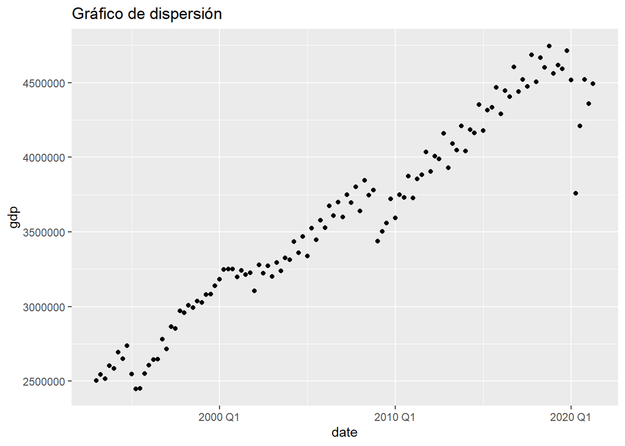

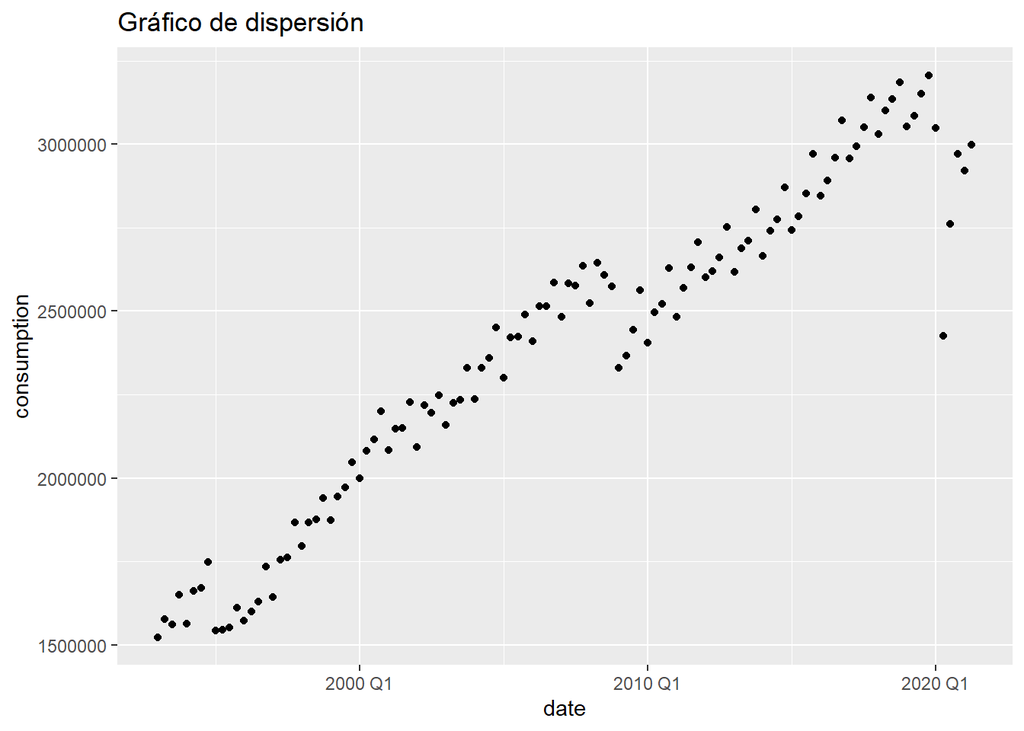

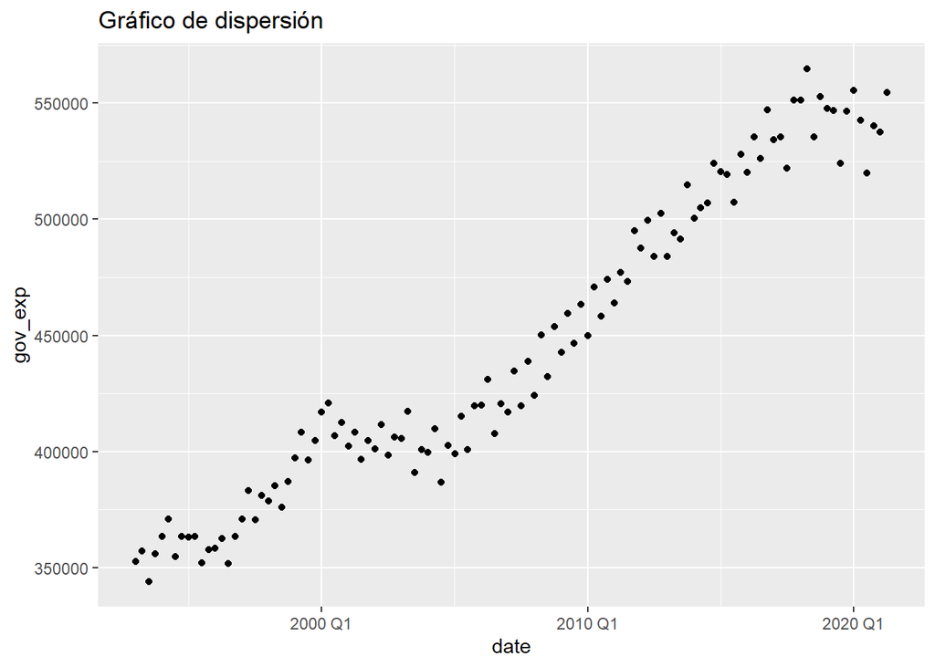

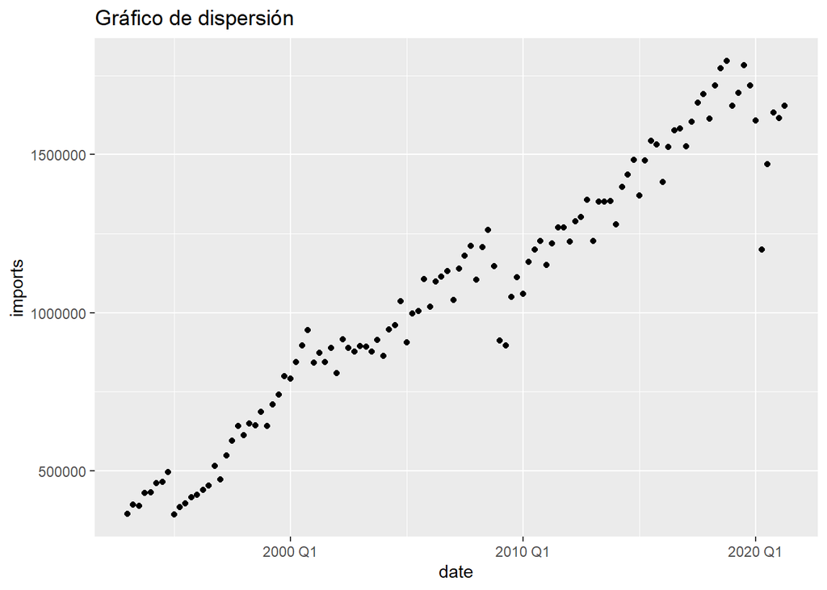

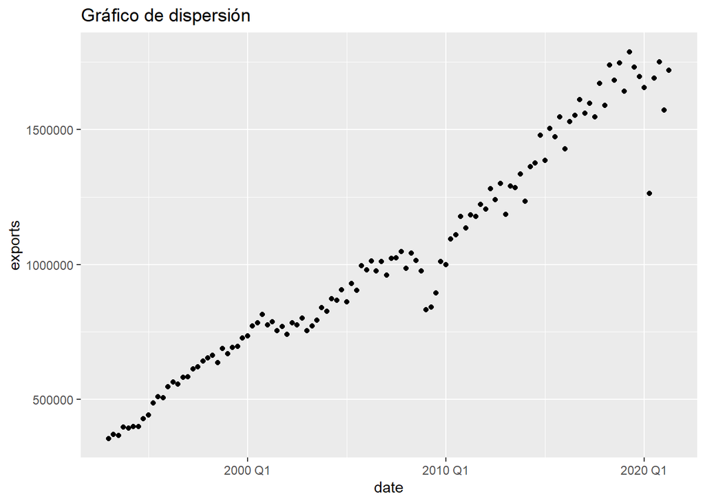

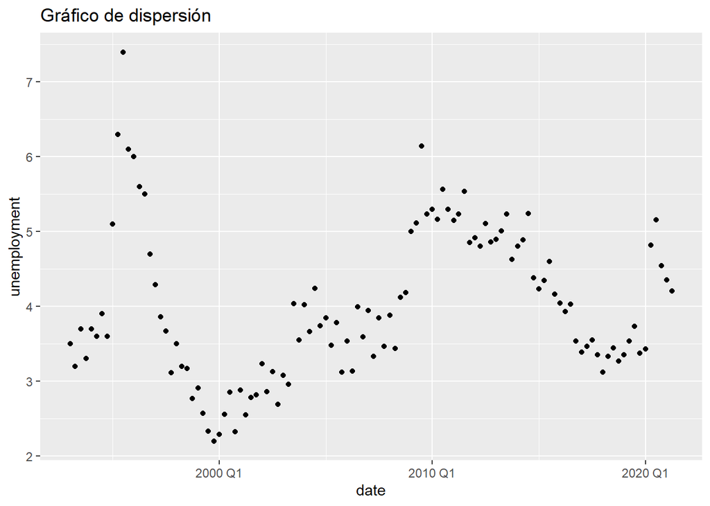

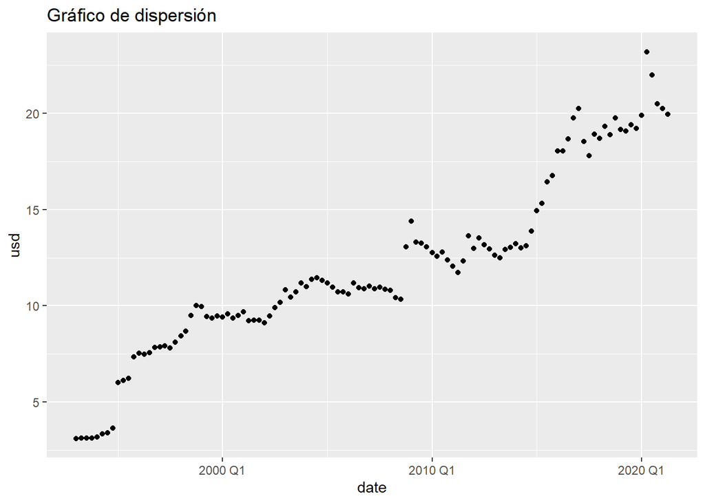

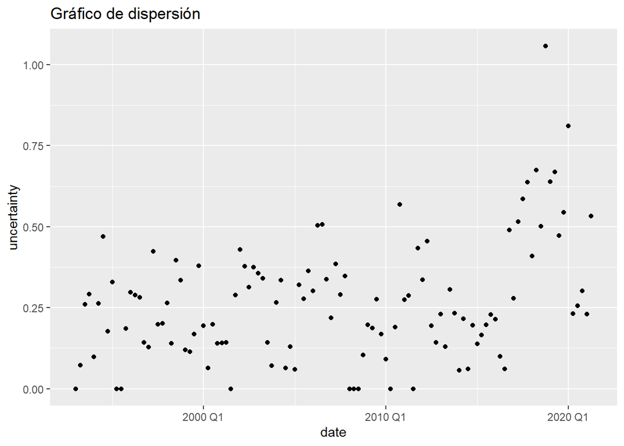

```r
i2 <- 1
for (i in select(gdp, gdp:uncertainty)){
  i2 <- i2 + 1
  if (!is.na(names(gdp)[i2])){
    print(ggplot(gdp) +
      geom_point(aes(x = date, y = i)) +
      ylab(names(gdp)[i2]) +
      ggtitle("Gráfico de dispersión"))
  }
}
```

#### Gráficos de tiempo

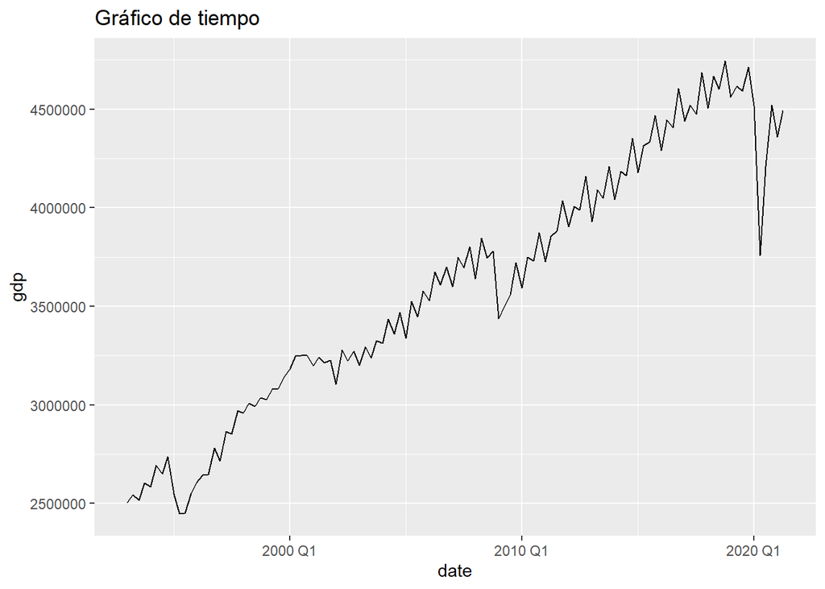

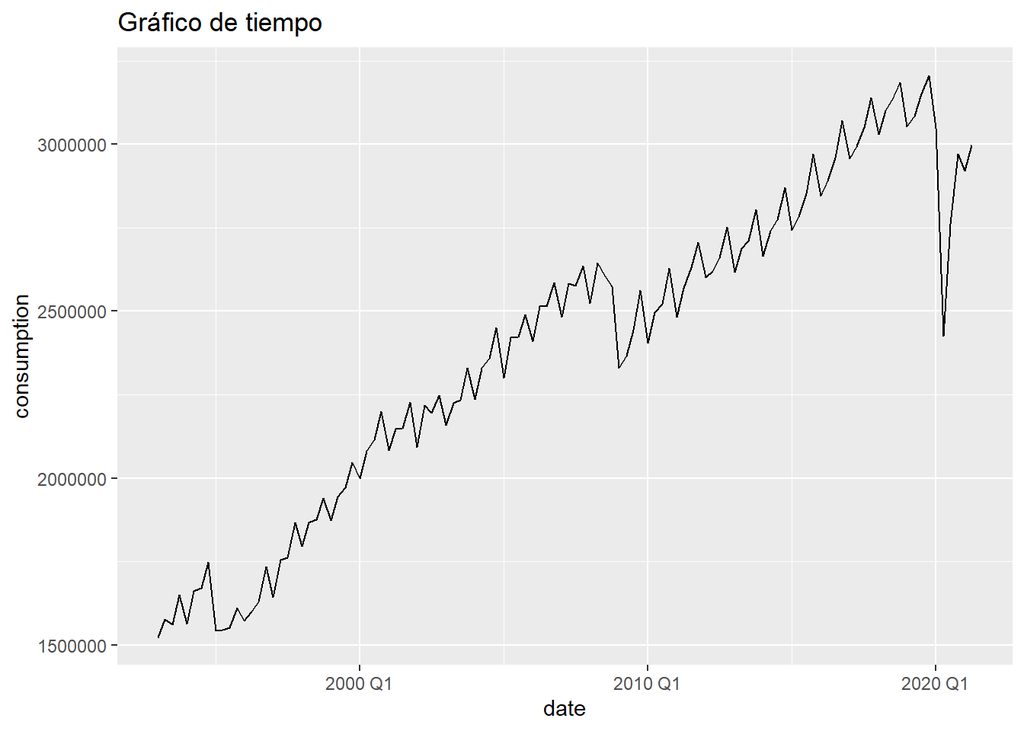

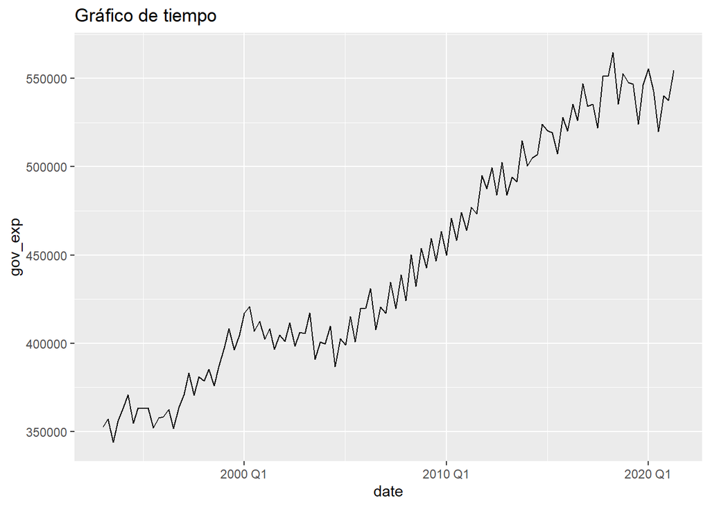

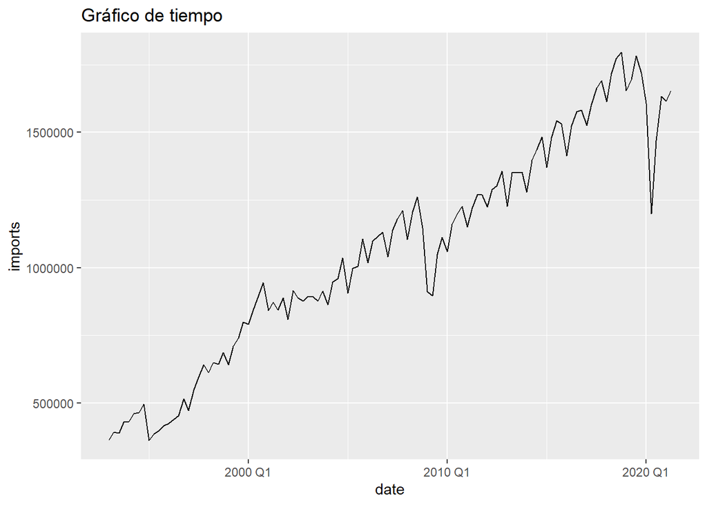

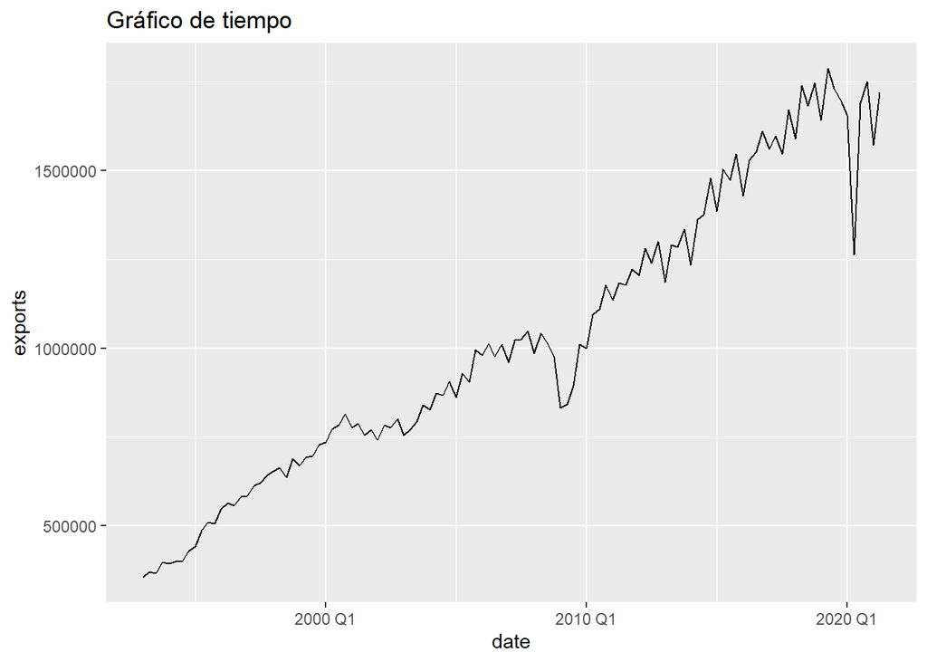

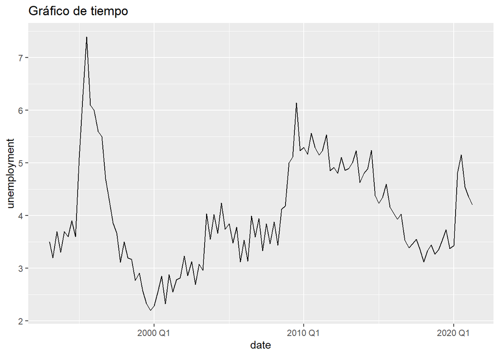

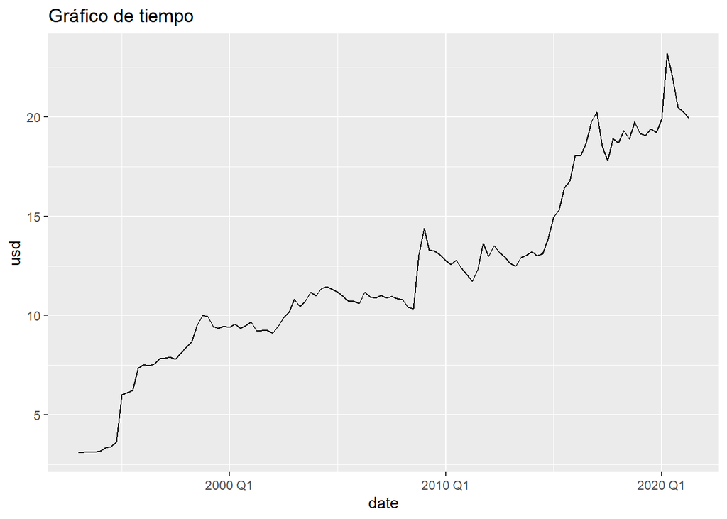

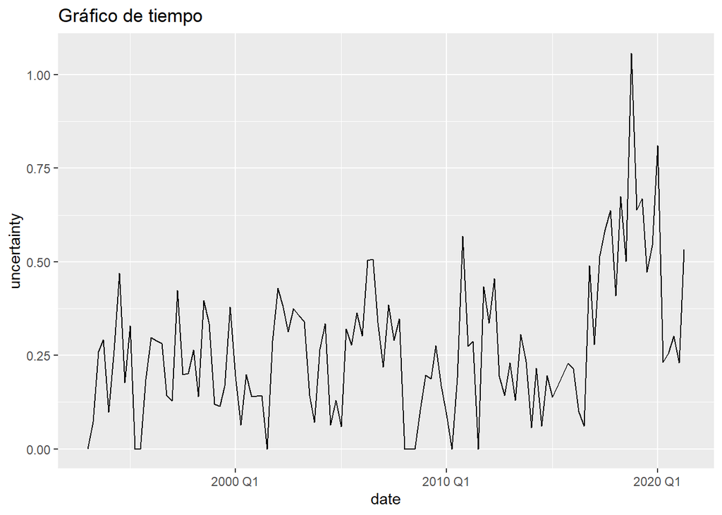

```r
i2 <- 1
for (i in select(gdp, gdp:uncertainty)){
  i2 <- i2 + 1
  if (!is.na(names(gdp)[i2])){
    print(ggplot(gdp) +
      geom_line(aes(x = date, y = i)) +
      ylab(names(gdp)[i2]) +
      ggtitle("Gráfico de tiempo"))
  }
}
```

#### Gráficos de estacionalidad

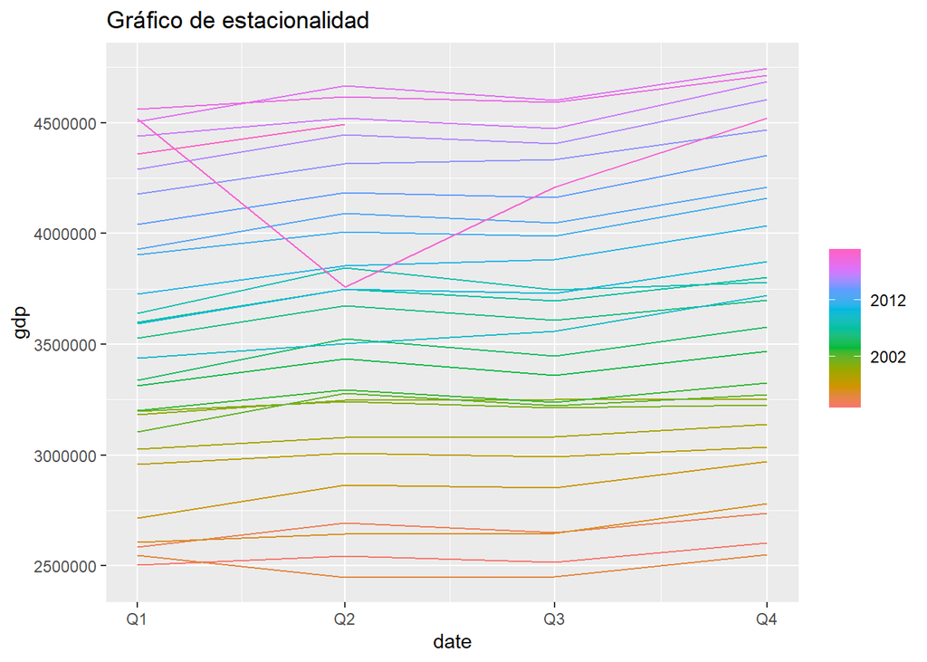

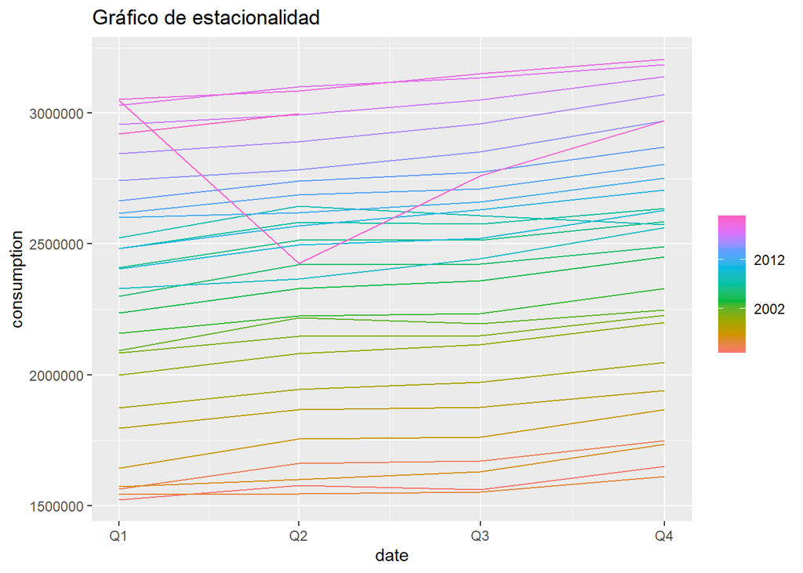

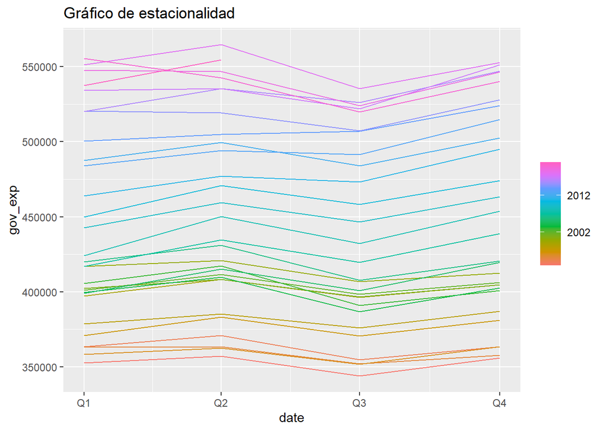

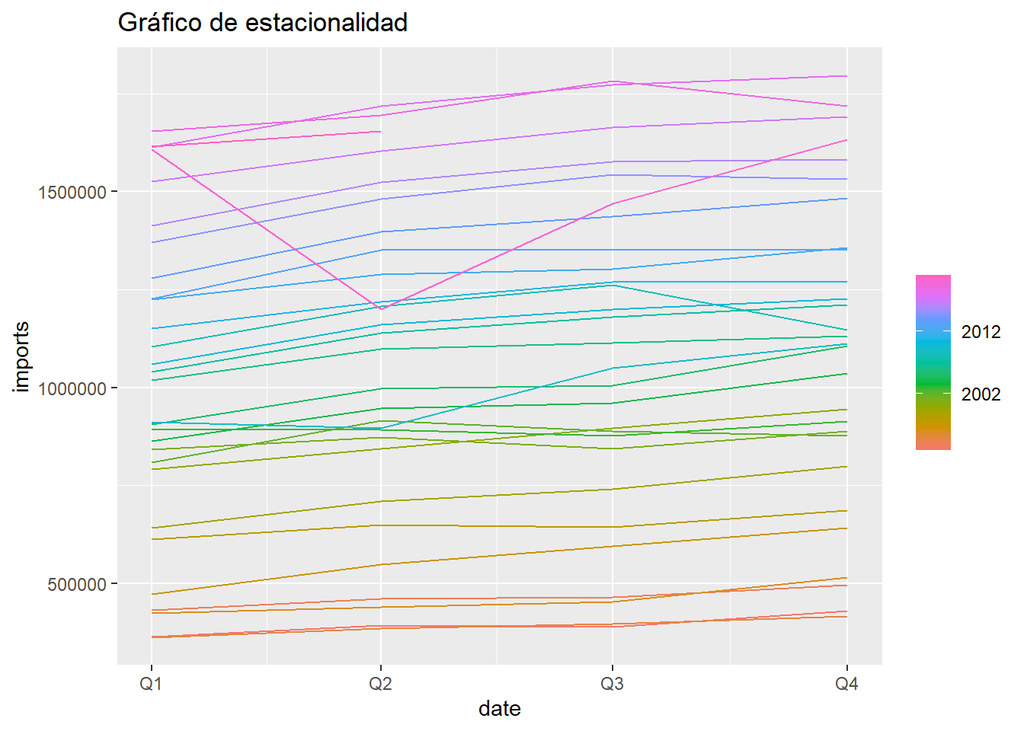

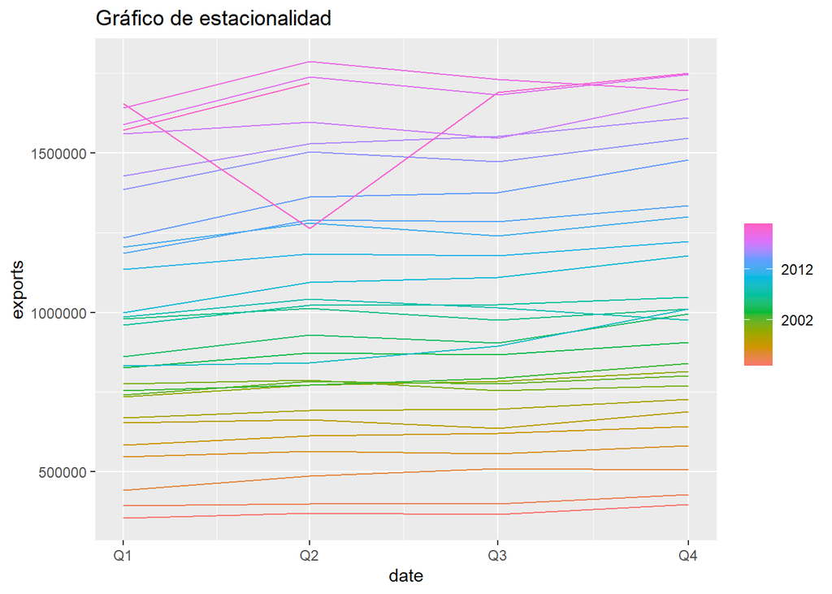

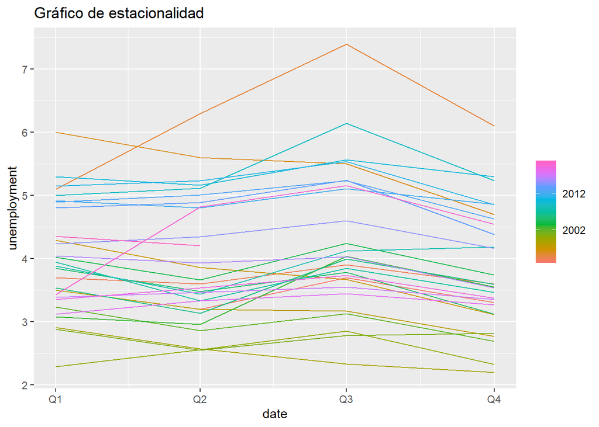

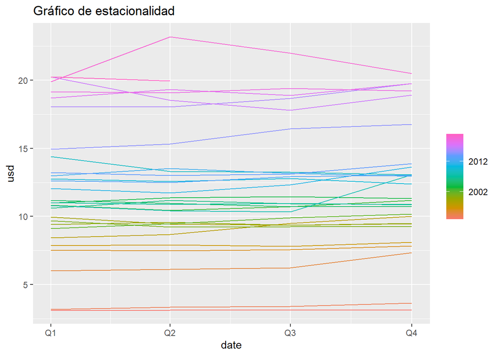

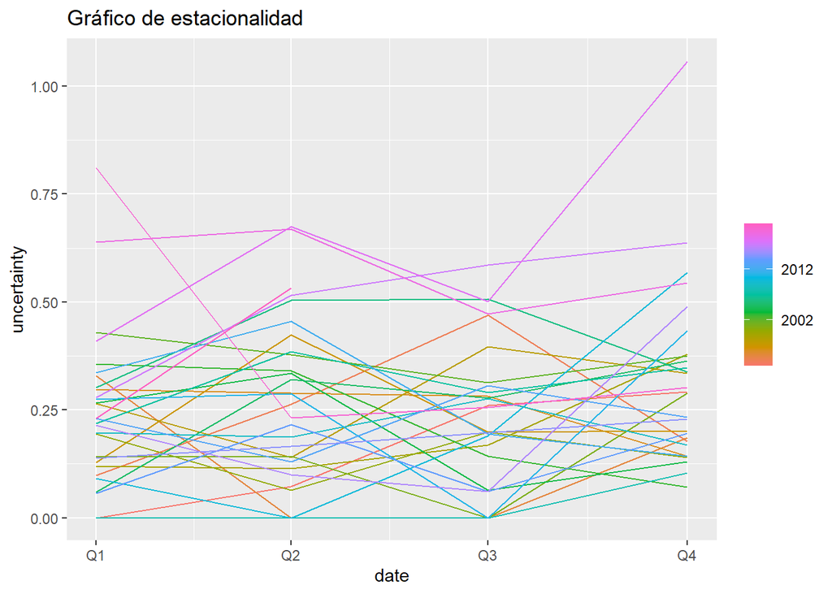

```r
i2 <- 1
for (i in select(gdp, gdp:uncertainty)){
  i2 <- i2 + 1
  if (!is.na(names(gdp)[i2])){
    print(gg_season(gdp, i) +
      ylab(names(gdp)[i2]) +
      ggtitle("Gráfico de estacionalidad"))
  }
}
```

#### Descomposición

```r
dcmp <- gdp %>%
  model(Descomposicion = STL(gdp))
components(dcmp)
```

```
# A dable: 114 x 7 [1Q]
# Key:     .model [1]
# :        gdp = trend + season_year + remainder
   .model            date      gdp    trend season_year remainder season_adjust
   <chr>            <qtr>    <dbl>    <dbl>       <dbl>     <dbl>         <dbl>
 1 Descomposicion 1993 Q1 2502224. 2515226.     -20504.     7502.      2522728.
 2 Descomposicion 1993 Q2 2542759. 2534487.       6304.     1969.      2536455.
 3 Descomposicion 1993 Q3 2516565. 2555721.     -26829.   -12327.      2543393.
 4 Descomposicion 1993 Q4 2604024. 2578901.      40535.   -15413.      2563489.
 5 Descomposicion 1994 Q1 2585847. 2616584.     -20515.   -10221.      2606363.
 6 Descomposicion 1994 Q2 2693132. 2652317.       6937.    33877.      2686194.
 7 Descomposicion 1994 Q3 2650688. 2666961.     -26095.     9822.      2676783.
 8 Descomposicion 1994 Q4 2738193. 2632662.      39195.    66336.      2698998.
 9 Descomposicion 1995 Q1 2547436. 2570827.     -20560.    -2830.      2567996.
10 Descomposicion 1995 Q2 2448930. 2515609.       7519.   -74198.      2441411.
# … with 104 more rows
```

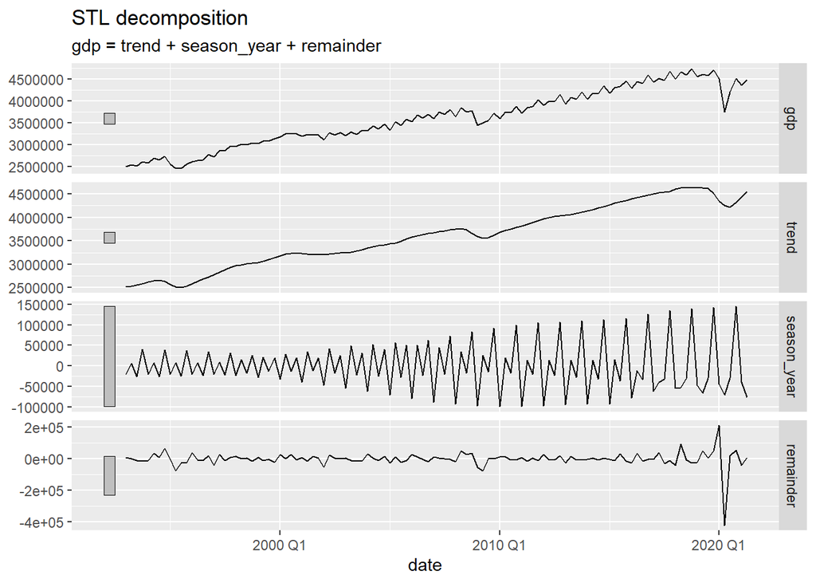

```r
autoplot(components(dcmp))
```

### Análisis de correlación/autocorrelación

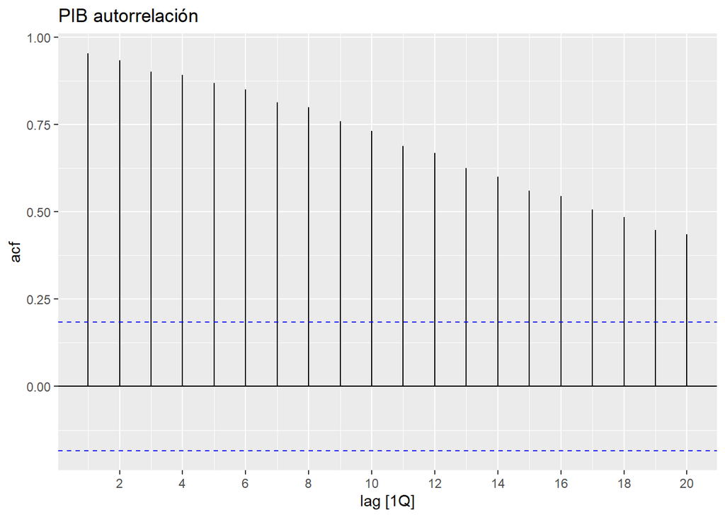

```r
gdp |>
  ACF(gdp) |>
  autoplot() + labs(title="PIB autorrelación")
```

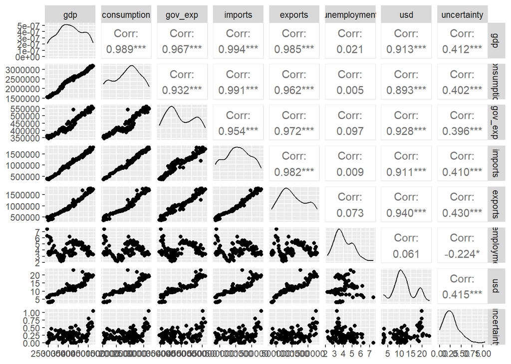

```r
gdp %>%
  as_tibble() %>%
  select(-date) %>%
  GGally::ggpairs()
```

### Transformaciones

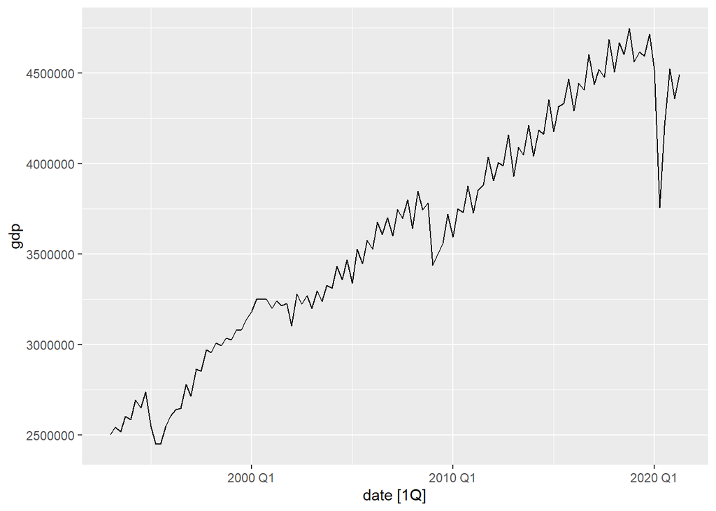

```r
autoplot(gdp, gdp)
```

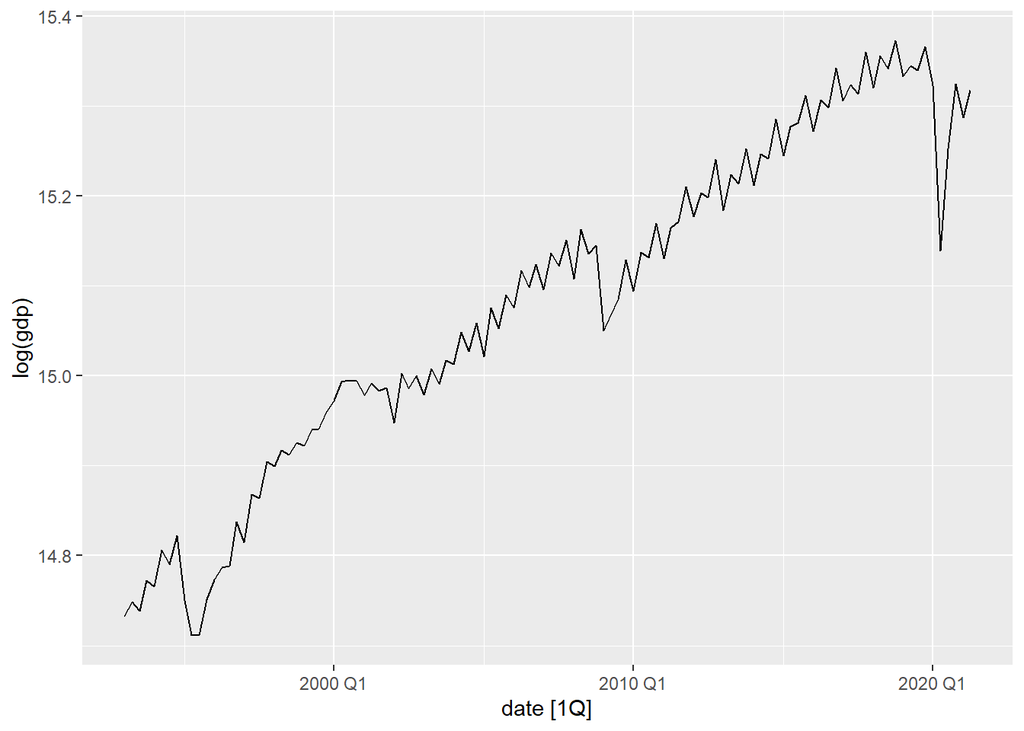

```r
autoplot(gdp, log(gdp))
```

Como pudimos ver en la descomposición, el PIB tenía una diferente variación en su estacionalidad a lo largo del tiempo, y junto con las gráficas anteriores, vemos que fue buena idea implementar una transformación logarítmica. En un futuro veremos en que modelos es conveniente el uso de esta transformación.

### Outliers

Podemos ver un claro outlier en el segundo y trecer trimestre de 2020, esto ocasionado claramente por la pandemia.

## 3.3 Especificación de modelos

### Entrenamiento

```r
(train <- gdp %>% filter_index('2000' ~ .))
```

```
# A tsibble: 86 x 9 [1Q]
      date      gdp consumption gov_exp imports exports unemploy…¹   usd uncer…²
     <qtr>    <dbl>       <dbl>   <dbl>   <dbl>   <dbl>      <dbl> <dbl>   <dbl>
 1 2000 Q1 3181256.    1998820. 416850. 791720. 734846.       2.29  9.40  0.194
 2 2000 Q2 3248642.    2081967. 420797. 844792. 771249        2.56  9.57  0.0636
 3 2000 Q3 3252198.    2116043. 406947. 895782. 782768.       2.85  9.35  0.199
 4 2000 Q4 3250826.    2200777. 412389  944804. 815622.       2.33  9.50  0.140
 5 2001 Q1 3199030.    2083419. 402243  841208. 775435        2.88  9.68  0.141
 6 2001 Q2 3241882.    2147364. 408302. 873444. 788422        2.55  9.21  0.142
 7 2001 Q3 3214352.    2149689. 396516. 843634. 753876.       2.78  9.24  0
 8 2001 Q4 3225357.    2227610. 404704. 889567  770568.       2.81  9.24  0.289
 9 2002 Q1 3103885.    2092057. 401123. 809323. 741000.       3.23  9.11  0.429
10 2002 Q2 3278091.    2218139. 411520. 915446. 783374.       2.86  9.48  0.378
# … with 76 more rows, and abbreviated variable names ¹unemployment,
#   ²uncertainty
```

### Modelos benchmark

```r
fit1 <- model(train,
             snaive = SNAIVE(log(gdp)),
             drift = RW(log(gdp) ~ drift())
             )
```

### Modelos ETS

Utilizamos un ETS automático. Al tener estacionalidad, usaremos estacionalidad multiplicativa, una con tendencía aditiva (Holt Winters) y otra amortiguada (Holt Winters Damped).

```r
fit2 <- model(train,
              hw = ETS(gdp ~ error("M") + trend("A") + season("M")),
              hwa = ETS(gdp ~ error("M") + trend("Ad") + season("M")),
              auto = ETS(gdp))
```

### Modelos ARIMA

```r
features(train, log(gdp), unitroot_kpss)
```

```
# A tibble: 1 × 2
  kpss_stat kpss_pvalue
      <dbl>       <dbl>
1      2.15        0.01
```

```r
features(train, log(gdp), unitroot_ndiffs)
```

```
# A tibble: 1 × 1
  ndiffs
   <int>
1      1
```

```r
atrain <- mutate(train, diff = difference(log(gdp), 1))
features(atrain, diff, unitroot_kpss)
```

```
# A tibble: 1 × 2
  kpss_stat kpss_pvalue
      <dbl>       <dbl>
1    0.0602         0.1
```

```r
features(atrain, diff, unitroot_ndiffs)
```

```
# A tibble: 1 × 1
  ndiffs
   <int>
1      0
```

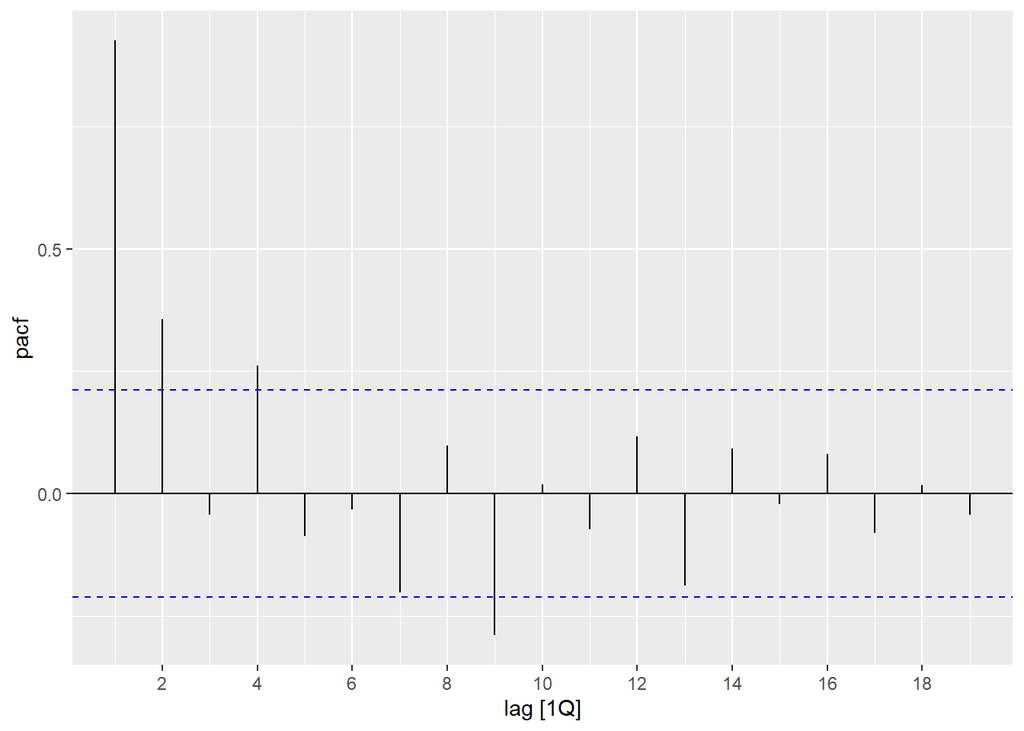

```r
train %>% PACF(log(gdp)) %>% autoplot()
```

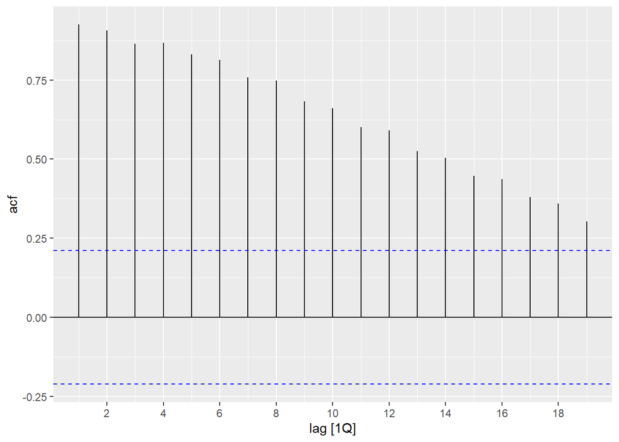

```r
train %>% ACF(log(gdp)) %>% autoplot()
```

Podemos ver que necesita una diferencia para poder ser estacionaria. Por lo tanto, haremos un modelo con d = 1.

De igual forma vemos que PACF tiene dos picos iniciales. Por lo tanto, incluimos p = 2.

Vemos que ACF decae lentamente. Por lo tanto, incluimos q = 0.

También haremos un ARIMA automático.

```r
fit3 <- model(train,
              arima = ARIMA(gdp ~ pdq(2,1,0) + PDQ(0,0,0)),
              arima_auto = ARIMA(gdp ~ PDQ(0,0,0)),
              )
```

### Modelo SARIMA

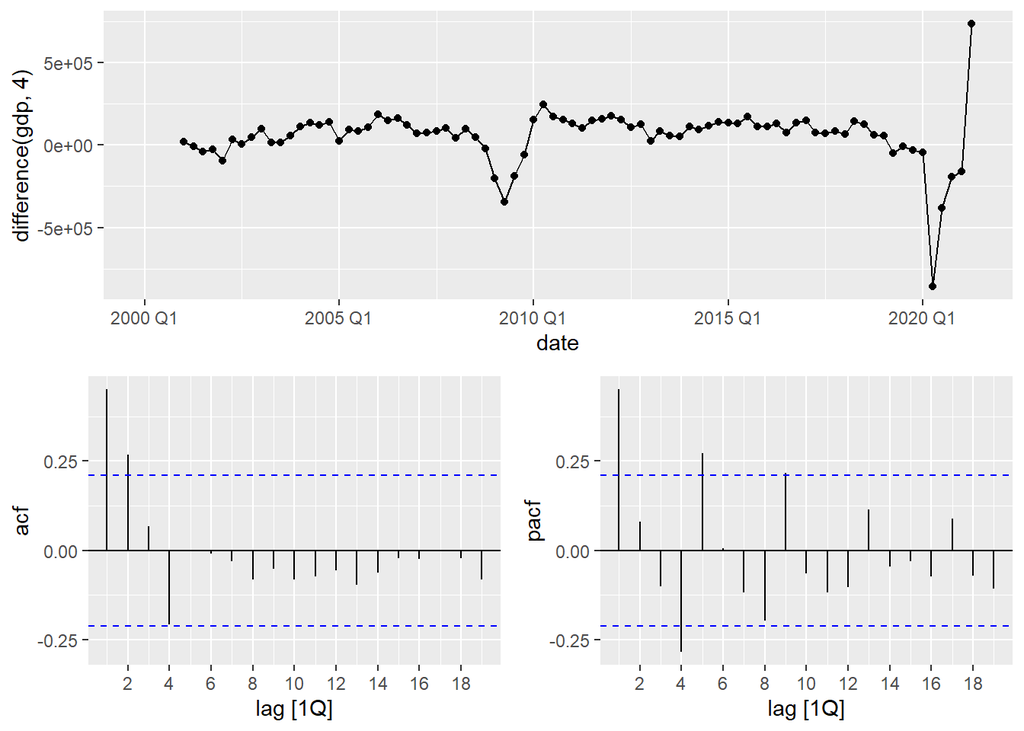

```r
train %>% gg_tsdisplay(difference(gdp, 4) , plot_type='partial')
```

```r
fit4 <- model(train,
              sarima = ARIMA(gdp ~ pdq(0,0,2) + PDQ(0,1,1)),
              sarima2 = ARIMA(gdp ~ pdq(1,0,0) + PDQ(1,1,0)),
              sarima3 = ARIMA(gdp ~ pdq(1,0,2) + PDQ(1,1,1)),
              sarima4 = ARIMA(gdp ~ pdq(1,1,2) + PDQ(1,1,1)),
              sarima_auto = ARIMA(gdp)
              )
report(fit4)
```

```
# A tibble: 5 × 8
  .model            sigma2 log_lik   AIC  AICc   BIC ar_roots  ma_roots
  <chr>              <dbl>   <dbl> <dbl> <dbl> <dbl> <list>    <list>
1 sarima      15643740952.  -1079. 2167. 2168. 2179. <cpl [0]> <cpl [6]>
2 sarima2     15349787302.  -1078. 2163. 2164. 2173. <cpl [5]> <cpl [0]>
3 sarima3     14212366133.  -1073. 2161. 2162. 2178. <cpl [5]> <cpl [6]>
4 sarima4     14341110273.  -1063. 2138. 2139. 2152. <cpl [5]> <cpl [6]>
5 sarima_auto 14579053171.  -1115. 2240. 2240. 2252. <cpl [5]> <cpl [5]>
```

### Modelos de regresión lienal

Como vimos en DEA, la mayoría de variables tienen gran correlación con el PIB. Para confirmar esto haremos un FOrwards Stepwise regression:

```r
model(train,
      i = TSLM(gdp ~ consumption),
      ii = TSLM(gdp ~ exports),
      iii = TSLM(gdp ~ gov_exp),
      iv = TSLM(gdp ~ imports),
      v = TSLM(gdp ~ uncertainty),
      vi = TSLM(gdp ~ unemployment),
      vii = TSLM(gdp ~ usd)
      ) %>% glance() %>%
  select(.model, AICc, BIC) %>% arrange(AICc)
```

```
# A tibble: 7 × 3
  .model  AICc   BIC
  <chr>  <dbl> <dbl>
1 iv     1932. 1939.
2 i      1955. 1962.
3 ii     1966. 1973.
4 iii    2053. 2060.
5 vii    2144. 2151.
6 v      2237. 2245.
7 vi     2253. 2260.
```

```r
model(train,
      o = TSLM(gdp ~ imports),
      i = TSLM(gdp ~ imports + consumption),
      ii = TSLM(gdp ~ imports + exports),
      iii = TSLM(gdp ~ imports + gov_exp),
      iv = TSLM(gdp ~ imports + uncertainty),
      v = TSLM(gdp ~ imports + unemployment),
      vi = TSLM(gdp ~ imports + usd)
      ) %>% glance() %>%
  select(.model, AICc, BIC) %>% arrange(AICc)
```

```
# A tibble: 7 × 3
  .model  AICc   BIC
  <chr>  <dbl> <dbl>
1 iii    1900. 1909.
2 i      1910. 1919.
3 ii     1920. 1929.
4 v      1929. 1939.
5 o      1932. 1939.
6 vi     1933. 1942.
7 iv     1933. 1943.
```

```r
model(train,
      o = TSLM(gdp ~ imports + gov_exp),
      i = TSLM(gdp ~ imports + gov_exp + consumption),
      ii = TSLM(gdp ~ imports + gov_exp + exports),
      iii = TSLM(gdp ~ imports + gov_exp + uncertainty),
      iv = TSLM(gdp ~ imports + gov_exp + unemployment),
      v = TSLM(gdp ~ imports + gov_exp + usd)
      ) %>% glance() %>%
  select(.model, AICc, BIC) %>% arrange(AICc)
```

```
# A tibble: 6 × 3
  .model  AICc   BIC
  <chr>  <dbl> <dbl>
1 i      1830. 1842.
2 v      1896. 1907.
3 o      1900. 1909.
4 ii     1901. 1913.
5 iv     1901. 1913.
6 iii    1902. 1913.
```

```r
model(train,
      o = TSLM(gdp ~ imports + gov_exp + consumption),
      i = TSLM(gdp ~ imports + gov_exp + consumption + exports),
      ii = TSLM(gdp ~ imports + gov_exp + consumption + uncertainty),
      iii = TSLM(gdp ~ imports + gov_exp + consumption + unemployment),
      iv = TSLM(gdp ~ imports + gov_exp + consumption + usd)
      ) %>% glance() %>%
  select(.model, AICc, BIC) %>% arrange(AICc)
```

```
# A tibble: 5 × 3
  .model  AICc   BIC
  <chr>  <dbl> <dbl>
1 iv     1820. 1834.
2 i      1827. 1840.
3 ii     1830. 1843.
4 o      1830. 1842.
5 iii    1832. 1845.
```

```r
model(train,
      o = TSLM(gdp ~ imports + gov_exp + consumption + usd),
      i = TSLM(gdp ~ imports + gov_exp + consumption + usd + exports),
      ii = TSLM(gdp ~ imports + gov_exp + consumption + usd + uncertainty),
      iii = TSLM(gdp ~ imports + gov_exp + consumption + usd + unemployment)
      ) %>% glance() %>%
  select(.model, AICc, BIC) %>% arrange(AICc)
```

```
# A tibble: 4 × 3
  .model  AICc   BIC
  <chr>  <dbl> <dbl>
1 i      1800. 1816.
2 iii    1820. 1836.
3 o      1820. 1834.
4 ii     1821. 1837.
```

```r
model(train,
      o = TSLM(gdp ~ imports + gov_exp + consumption + usd + exports),
      i = TSLM(gdp ~ imports + gov_exp + consumption + usd + exports + uncertainty),
      ii = TSLM(gdp ~ imports + gov_exp + consumption + usd + exports + unemployment)
      ) %>% glance() %>%
  select(.model, AICc, BIC) %>% arrange(AICc)
```

```
# A tibble: 3 × 3
  .model  AICc   BIC
  <chr>  <dbl> <dbl>
1 ii     1799. 1817.
2 i      1800. 1818.
3 o      1800. 1816.
```

```r
model(train,
      o = TSLM(gdp ~ imports + gov_exp + consumption + usd + exports + unemployment),
      i = TSLM(gdp ~ imports + gov_exp + consumption + usd + exports + unemployment + uncertainty)
      ) %>% glance() %>%
  select(.model, AICc, BIC) %>% arrange(AICc)
```

```
# A tibble: 2 × 3
  .model  AICc   BIC
  <chr>  <dbl> <dbl>
1 i      1794. 1814.
2 o      1799. 1817.
```

```r
model(train,
      o = TSLM(gdp ~ imports + gov_exp + consumption + usd + exports + unemployment),
      i = TSLM(gdp ~ imports + gov_exp + consumption + usd + exports + unemployment + uncertainty)
      ) %>% glance() %>%
  select(.model, AICc, BIC) %>% arrange(AICc)
```

```
# A tibble: 2 × 3
  .model  AICc   BIC
  <chr>  <dbl> <dbl>
1 i      1794. 1814.
2 o      1799. 1817.
```

Como podemos ver, el mejor modelo incluye todas las predictoras.

```r
fit5 <- model(train,
      regresion = TSLM(gdp ~ imports + gov_exp + consumption + usd + exports + unemployment + uncertainty))
```

### Modelos de regresión dinamica

Una regresión con valores automáticos y otras dos con valores definidos.

```r
fit6 <- model(train,
              dinamica = ARIMA(gdp ~ imports + gov_exp + consumption + usd + exports + unemployment + uncertainty),
              dinamica2 = ARIMA(gdp ~ imports + gov_exp + consumption + usd + exports + unemployment + uncertainty + pdq(1,0,2) + PDQ(1,1,1)),
              dinamica3 = ARIMA(gdp ~ imports + gov_exp + consumption + usd + exports + unemployment + uncertainty + pdq(1,1,2) + PDQ(1,1,1)))
```

### Modelos de regresión lineal más dummies

Incluimos dos dummies para cubrir los dos trimestres de la pandemia.

```r
(train2 <- train %>% mutate(
  q2_20 = if_else(date == yearquarter("2020 Q2"),1,0),
  q3_20 = if_else(date == yearquarter("2020 Q3"),1,0)
))
```

```
# A tsibble: 86 x 11 [1Q]
      date      gdp consum…¹ gov_exp imports exports unemp…²   usd uncer…³ q2_20
     <qtr>    <dbl>    <dbl>   <dbl>   <dbl>   <dbl>   <dbl> <dbl>   <dbl> <dbl>
 1 2000 Q1 3181256. 1998820. 416850. 791720. 734846.    2.29  9.40  0.194      0
 2 2000 Q2 3248642. 2081967. 420797. 844792. 771249     2.56  9.57  0.0636     0
 3 2000 Q3 3252198. 2116043. 406947. 895782. 782768.    2.85  9.35  0.199      0
 4 2000 Q4 3250826. 2200777. 412389  944804. 815622.    2.33  9.50  0.140      0
 5 2001 Q1 3199030. 2083419. 402243  841208. 775435     2.88  9.68  0.141      0
 6 2001 Q2 3241882. 2147364. 408302. 873444. 788422     2.55  9.21  0.142      0
 7 2001 Q3 3214352. 2149689. 396516. 843634. 753876.    2.78  9.24  0          0
 8 2001 Q4 3225357. 2227610. 404704. 889567  770568.    2.81  9.24  0.289      0
 9 2002 Q1 3103885. 2092057. 401123. 809323. 741000.    3.23  9.11  0.429      0
10 2002 Q2 3278091. 2218139. 411520. 915446. 783374.    2.86  9.48  0.378      0
# … with 76 more rows, 1 more variable: q3_20 <dbl>, and abbreviated variable
#   names ¹consumption, ²unemployment, ³uncertainty
```

También hacemos un segundo modelo con dummies de estacionalidad y tendencia:

```r
fit7 <- model(train2,
              dummy1= TSLM(gdp ~ imports + gov_exp + consumption + usd + exports + unemployment + uncertainty + q2_20 + q3_20),
              dummy2= TSLM(gdp ~ imports + gov_exp + consumption + usd + exports + unemployment + uncertainty + season() + trend() + q2_20 + q3_20))
```

### Modelos de regresión armónica

Modelo con k = 1, con valores ARIMA definidos.

```r
fit8 <- train %>%
  model(
    k1 = ARIMA(gdp ~ imports + gov_exp + consumption + usd + exports + unemployment + uncertainty+ fourier(K = 1) + pdq(1,0,2) + PDQ(0,0,0))
  )
glance(fit8)
```

```
# A tibble: 1 × 8
  .model     sigma2 log_lik   AIC  AICc   BIC ar_roots  ma_roots
  <chr>       <dbl>   <dbl> <dbl> <dbl> <dbl> <list>    <list>
1 k1     915570049.  -1003. 2033. 2039. 2068. <cpl [1]> <cpl [2]>
```

### Modelos de regresión armónica con dummies

```r
fit9 <- train2 %>%
  model(
    k2 = ARIMA(gdp ~ imports + gov_exp + consumption + usd + exports + unemployment + uncertainty+ fourier(K = 1) + pdq(1,1,2) + PDQ(0,0,0)  + q2_20 + q3_20),
    k3 = TSLM(gdp ~ imports + gov_exp + consumption + usd + exports + unemployment + uncertainty+ fourier(K = 1) + q2_20 + q3_20)
  )
glance(fit9)
```

```
# A tibble: 2 × 17
  .model     sigma2 log_lik   AIC  AICc   BIC ar_roots  ma_roots r_squ…¹ adj_r…²
  <chr>       <dbl>   <dbl> <dbl> <dbl> <dbl> <list>    <list>     <dbl>   <dbl>
1 k2     722626945.   -981. 1991. 1998. 2028. <cpl [1]> <cpl>     NA      NA
2 k3     957785732.  -1005. 1792. 1797. 1823. <NULL>    <NULL>     0.996   0.996
# … with 7 more variables: statistic <dbl>, p_value <dbl>, df <int>, CV <dbl>,
#   deviance <dbl>, df.residual <int>, rank <int>, and abbreviated variable
#   names ¹r_squared, ²adj_r_squared
```